# Making Predictions with Lines: Woolly Adelgid Data

The hemlock woolly adelgid is an insect native to East Asia. It feeds by sucking sap from hemlock and spruce trees. In its native range, HWA is not a serious pest because populations are managed by natural predators and host resistance. In eastern North America it is a destructive pest that seriously threatens hemlock trees.

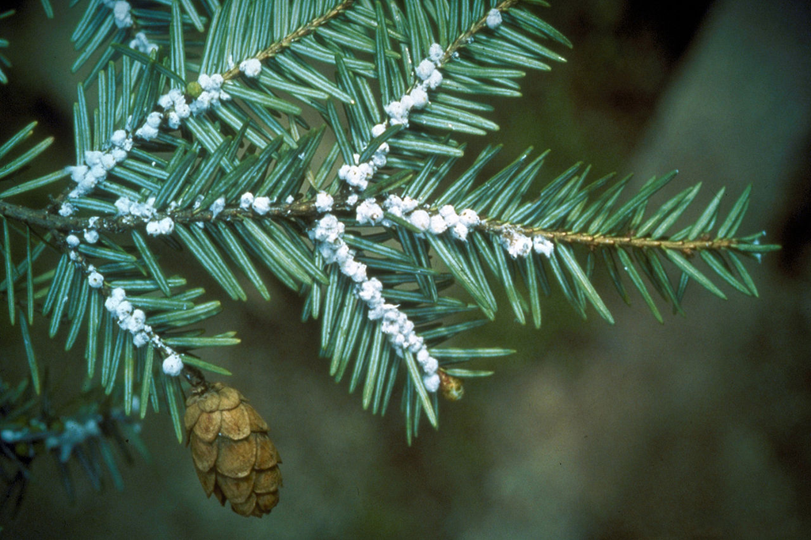

Picture of the woolly adelgid on hemlock. Connecticut Agricultural Experiment Station Archive, United States.

The data below show the number of US counties in which the woolly adelgid has been found over time.

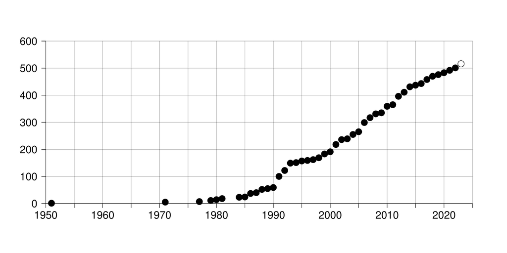

Woolly Adelgid Count of Infested US Counties by Year

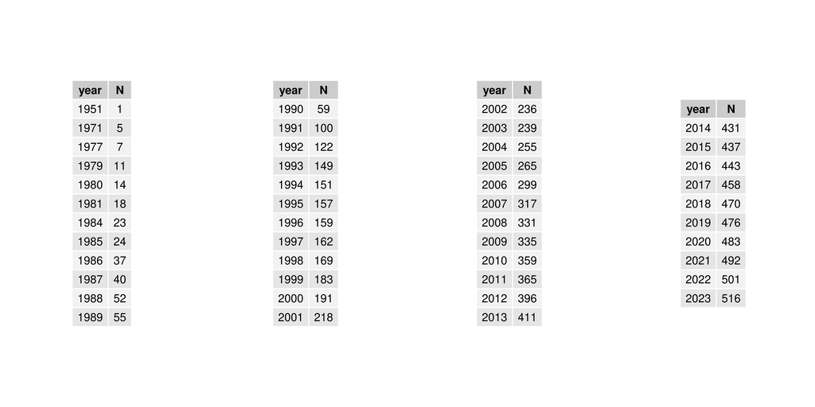

Woolly Adelgid Count of Infested US Counties by Year

## Exercise:

1. Pick 2 points on the graph where the year is *less* than 2023.
2. Figure out the equation of the line that runs through those points. Write this equation down.
3. Use that equation to predict the number of infested counties in 2023.
4. How close was your prediction to the actual value in 2023?
5. Does the infestation seem to be speeding up or slowing down recently?

The raw data for this project can be obtained from Virginia Tech Entomology here:

https://hemlock-woolly-adelgid-national-initiative-gmsts.hub.arcgis.com/pages/distribution-maps